# MADS-DAV · Lesson 6 · Many dimensions

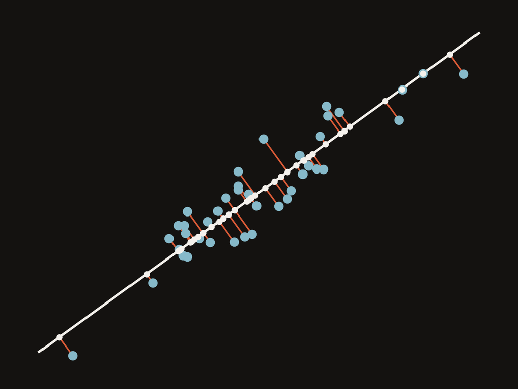

MADS-DAV

Data Analysis & Visualisation

# Many dimensions

How to look at data with hundreds of columns, what a picture of it can and cannot show, and how text becomes a vector.

Lesson 6

Hogeschool Utrecht

Lesson 6. Until now every dataset had a handful of columns, few enough to plot against each other. Today's do not: a handwritten digit is 784 numbers, a sentence from a language model 384, a piece of text counted by its three-letter sequences tens of thousands. Six questions. The first two are about looking at such data: PCA, which flattens it, and t-SNE, which you need when flattening is not enough. The third and fourth are about turning text and photos into vectors: by counting, and by reusing a model somebody else trained. The fifth is about chat data, where one row is often a single word. The last one is about a mistake that is easy to make with all of this: running k-means on a picture and reporting the clusters. The drawing on the cover is the whole idea of PCA: a line through a cloud, every point dropped onto it, and the vermilion strokes are what the line throws away.

Agenda

six questions

## Six questions for today

01

What does PCA show you?

The directions in which your data varies most, in the units you gave it.

02

When is a flat picture not enough?

When the data lies on a curved surface. t-SNE unrolls it, at a price.

03

How does text become a vector?

Count which three-letter sequences it contains. Then check what did the work.

04

Why use a model somebody else trained?

It is expensive to run and cheap to reuse. Pay once, then train on a laptop.

05

What is one row, when a row is “haha”?

A picture can only show what the rows contain.

06

Why did k-means find three clusters?

Because you asked for three.

Agenda

MADS-DAV · 2

The agenda as six questions; read them out. One and two are about looking at data with many columns: PCA, which squashes them into a few new axes, and t-SNE, which you need when the data lies on a curved surface. Three is about text: how a piece of text becomes a row of numbers by counting, and a published claim checked with exactly that method. Four is about using a model somebody else trained: why you compute its output once and store it, and how cosine similarity and a nearest neighbour already give you a classifier. Five is about chat data, where a row is often a single word. Six closes the lesson with a mistake many of you will be tempted to make: running k-means on a picture and reporting the clusters. Same rhythm as before: a question, real data with a reading guide, then the answer again in plain words. The notebooks follow along: 06.1 PCA and t-SNE, 06.2 counting characters, 06.3 the flower vectors, 06.4 your own vectors.

▲ question 01

what does PCA show you?

## PCA finds the directions in which your data varies most, measured in the units you gave it.

1 · Fit a line

Fit a line by picking the line the points lie closest to: it is also the line with the most spread. Then the next, at right angles: as many new axes as you had columns.

2 · Your units

Your units (milligram or kilogram) determine your variance, and so what PCA sees as spread. Be careful which units you hand it.

3 · How much

You can reduce the number of dimensions by dropping the last axes, but you always lose some information. PCA tells you exactly how much.

3

Question one. Every dataset so far had few enough columns to plot. Today's do not: a handwritten digit is 784 numbers, a sentence vector 384. There is no scatter plot of 784 dimensions. PCA is the oldest way to get to one, and it works in two steps. First it fits new axes: a line through the data, the one the points lie closest to, which is also the one with the most spread along it; then the best line at right angles to it, and so on, until there are exactly as many new axes as you had columns. Nothing is lost yet: it is the same data, described along different axes. Only then do you reduce, by dropping the last axes, the ones that carry the least spread. That always loses some information, and PCA tells you exactly how much: the share of the variance each axis carries. The catch is in the middle card: variance has units. Measure a mass in milligrams instead of kilograms and its variance is a trillion times bigger, so PCA will call it the most important direction for that reason alone. Notebook 06.1, sections 6.1.1 and 6.1.2.

■ 1 — what does PCA show you?

40 points, one line

## The line with the most spread loses the least

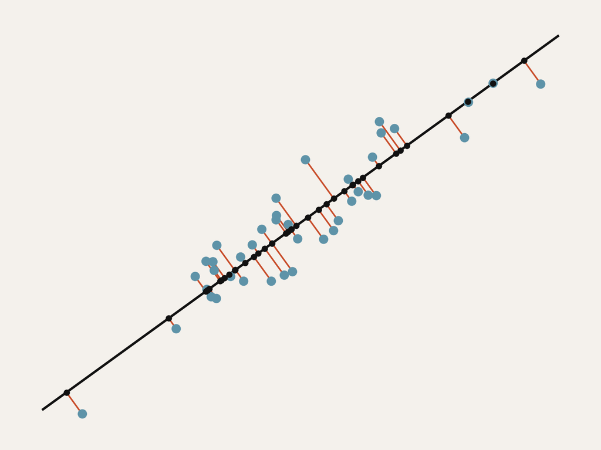

Black dots: every point dropped onto the line. That is what PCA keeps: one number per point, its position along the line.

Vermilion: the distance from each point to the line. That is what it throws away.

Turn the line, and the black spread shrinks exactly as fast as the vermilion grows. So the line with the most spread along it is the line closest to the points. That line is the first component of PCA.

1 / what does PCA show you?

MADS-DAV · 4

The whole idea of PCA in one sketch, from the start of notebook 06.1. Reducing two columns to one means choosing a line and dropping every point onto it. Each point splits into two pieces: where it lands along the line, and how far it sits from the line. By Pythagoras, distance to the centre squared equals position along the line squared plus distance to the line squared, and the left side does not depend on which line you chose. So summed over all points, more spread along the line means exactly less distance to the line. The line with the most spread is the projection that loses the least. That is the first principal component. The second is the best line at right angles to the first, and so on. Nothing here is about labels or groups: PCA only looks at spread. The data is centred first, which is why the line goes through the middle of the cloud.

■ 1 — what does PCA show you?

three columns that are really two

## PCA finds new axes, and you choose how many to keep

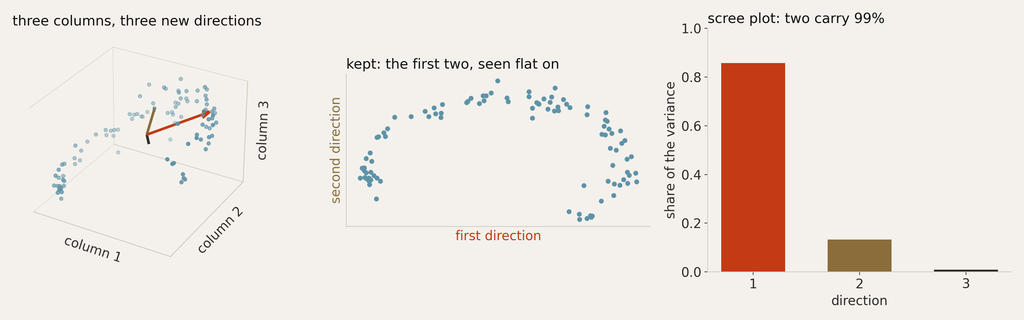

Left: 100 rows, three columns, the third almost a sum of the first two. The arrows are PCA’s three directions, each a mix of all three columns.

Middle: keep the first two directions and look straight at them: the curved strip, as it really is.

Right: the scree plot, the share of the spread per direction. Two carry 99%, so this picture shows nearly all of the data.

1 / what does PCA show you?

MADS-DAV · 5

The same idea one dimension up, on data built so the answer is known. A hundred points on a curved strip: two columns trace the strip, and the third is 0.1 times the first plus 0.3 times the second, plus a little noise. Three numbers per row, but every row lies close to one tilted plane. PCA finds three new directions. None of them is one of the original columns: each is a mixture of all three, which is what people mean by "PCA finds new axes". They are at right angles to each other, each has length one, and together they can describe any point exactly; dropping the last one is the projection. The scree plot shows how much of the spread each direction carries: 86, 13 and 1 percent. The first two carry 99 percent, so the flat picture in the middle is a picture of nearly all the data. Remember that number: on real data it is often much smaller, and then the picture shows much less. In the notebook this is np.linalg.svd, with sklearn's PCA giving the same coordinates up to a sign.

■ 1 — what does PCA show you?

333 penguins, four measurements

## Change the unit, and the first component changes

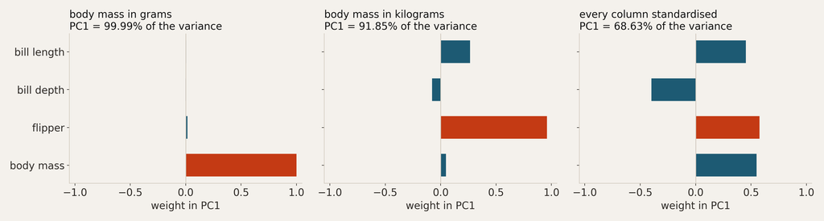

Grams: PC1 is body mass and nothing else, “99.99% of the variance”. Body mass varies by about 800 grams, bill depth by 2 millimetres.

Kilograms: the same birds, body mass divided by 1,000. PC1 is now flipper length. Nothing about the penguins changed.

Standardised: every column minus its mean, divided by its standard deviation. PC1 is size: bill length, flipper and mass together.

1 / what does PCA show you?

MADS-DAV · 6

The first way PCA goes wrong, with the penguins from lesson 2. PCA maximises spread, and spread has units. Body mass is measured in grams and varies by about 805 of them; bill depth varies by 2 millimetres. So almost all the spread in this table is grams, and the first component is the grams axis: 99.99 percent of the variance. That number in a report looks like a triumph. It is the symptom. The clearest way to see it is about units and not about penguins: divide body mass by a thousand and call it kilograms. Same birds, same information. Now the first component is flipper length, at 91.9 percent. A unit decided the answer. The fix is StandardScaler: subtract each column's mean and divide by its standard deviation, so one unit of every column is one standard deviation of that column. Then PC1 reads as a sentence: bill length, flipper and body mass all positive, so a penguin high on PC1 is a big penguin. Bill depth goes the other way: the long-billed species has shallow bills, lesson 5's Simpson case again. PC2, not shown, is bill shape.

■ 1 — what does PCA show you?

before and after standardising

## Standardise first, or PCA measures your units

step

PCA().fit(StandardScaler().fit_transform(measurements))

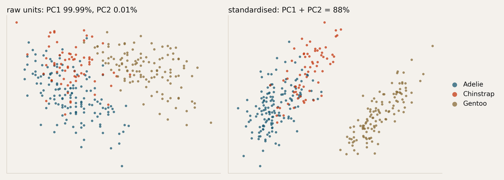

Left: raw units. Gentoo sits apart because they are heavy; Adelie and Chinstrap stay mixed. Their difference is bill shape, measured in millimetres.

And the vertical axis holds 0.01% of the variance, stretched to fill the frame. A projection always fills its frame; the title has to say how much it holds.

Right: standardised. Three species apart, two components hold 88%. Skip this step only if every column has the same unit, like pixels.

1 / what does PCA show you?

MADS-DAV · 7

It is not only about interpretation: the unscaled version is worse at the job. Along PC1, the ratio of between-species to within-species variance goes from 3.1 to 9.5 once the columns are standardised. On the left, Gentoo pulls away because they are heavy, but Adelie and Chinstrap stay mixed: what separates them is bill shape, and bill shape is in millimetres, which the grams drown out. On the right all three come apart. And look at what the left picture hides. Its two axes carry 99.99 and 0.01 percent of the variance. Drawn honestly it would be a horizontal line; matplotlib stretched the second axis to fill the panel, and a 0.01 percent component looks like half the picture. A projection plot always fills its frame, which is why the explained variance belongs in the title of every PCA picture you make. The rule: standardise before PCA, unless every column is in the same unit and you want the columns that vary more to count more. Pixel intensities, all 0 to 255, are the usual exception, and the MNIST digits later are not scaled for that reason.

● 01 — what does PCA show you?

PCA shows where your data varies most, in your units.

PCA turns many columns into a few new axes, each a mix of the old ones, ordered by how much of the spread they carry.

Spread has units. Standardise first, unless every column has the same unit.

Read the scree plot before the picture: two components show only their own share of the data.

8

Said again. PCA is a rotation of your data onto new axes, sorted by how much spread each one carries, after which you keep the first few. It does exactly that and nothing more: it does not know about groups, labels or meaning. Two habits follow. Standardise unless you have a reason not to, and write the reason down. And put the explained variance in the title of every PCA picture: two components of four columns can hold 88 percent, two components of 784 pixels hold 17 percent, and the reader cannot guess which. Last lesson's MAPE student is the warning here too: a number like 99.99 percent looks good until someone asks what it means.

▲ question 02

when is a flat picture not enough?

## When the data lies on a curved surface. A flat shadow cannot unroll it; t-SNE can, at a price.

1 · Curved

Much real data lies on a curved surface of few dimensions inside a space of many: the manifold hypothesis.

2 · Neighbours

t-SNE draws the points so that neighbours stay neighbours. It unrolls what PCA can only flatten.

3 · The price

Distances between groups, their sizes and the gaps mean nothing. And on pure noise it draws groups too.

9

Question two. PCA is a flat shadow: it picks a viewpoint and projects. That works when the data lies close to a flat surface. A lot of real data does not. It lies on a curved surface, and no viewpoint undoes a curve. The bet that this is true of real data, that 784 pixels of a digit really vary in only a few ways, is called the manifold hypothesis. t-SNE is built for that case: it does not look for a viewpoint, it looks for an arrangement in which each point keeps its nearest neighbours. It pays for that with everything else: how far apart two groups are, how big they are, whether a gap is real. And it has a setting, perplexity, that changes the picture. Today: when to use which, what you may read from a t-SNE picture, and what it does to data with nothing in it. Notebook 06.1, sections 6.1.3 to 6.1.6.

■ 2 — when is a flat picture not enough?

1,000 points on a rolled-up sheet

## PCA casts a shadow; t-SNE unrolls the sheet

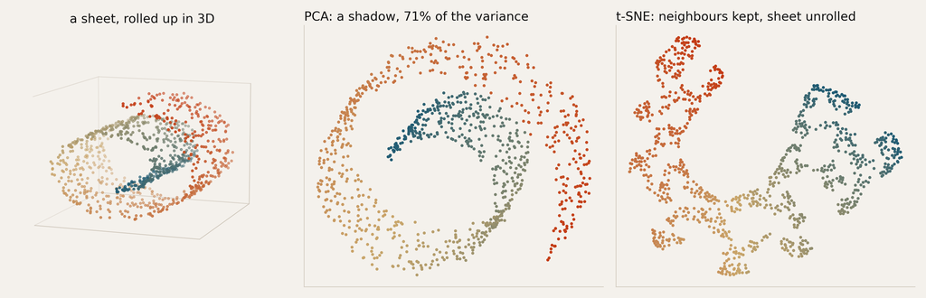

Left: a flat sheet, rolled up in three dimensions. The colour is the position along the sheet, the one thing a good picture should keep.

Middle: PCA keeps 71% of the variance and shows the roll from the side. Points from opposite ends of the sheet land next to each other.

Right: t-SNE keeps every point near its neighbours, and the colour runs end to end. But it tears the sheet into clumps: those gaps are not in the data.

2 / when is a flat picture not enough?

MADS-DAV · 10

The swiss roll is the standard dataset for seeing the limit of a flat shadow. It is a two-dimensional sheet, rolled up inside three dimensions, so the two numbers that really describe a point are where it sits along the sheet and across it. The colour shows the position along the sheet. PCA keeps 71 percent of the variance, which sounds like most of the data, and the picture is a spiral seen from the side. Look at where the colours land: the two ends of the sheet, as far apart along it as two points can be, sit next to each other. The shadow is faithful to the 3D shape and useless for the question which points are near each other on the sheet. t-SNE asks that question directly. It looks for a 2D arrangement in which each point's nearest neighbours in 3D are still its nearest neighbours. The colour now runs from one end to the other: the sheet is more or less unrolled. The price is visible too: the sheet is torn into clumps with gaps between them, and those gaps are not in the data. t-SNE kept the neighbours and gave up everything else. Notebook 06.1, section 6.1.3.

■ 2 — when is a flat picture not enough?

the manifold hypothesis

## The manifold hypothesis: many columns, few real dimensions

Real data with many dimensions, such as images, sound or text, will often lie close to a surface with far fewer dimensions: a manifold.

A manifold is curved as a whole and flat close up, like the earth: round, but flat as seen from your street.

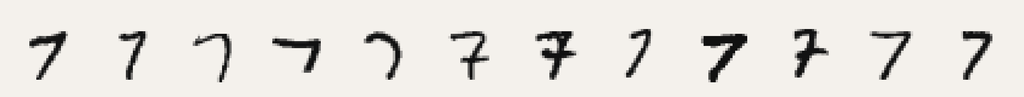

784 numbers

A handwritten digit is 28 × 28 pixels: 784 numbers, so one point in a space with 784 dimensions.

a few ways

Almost every point in that space is noise. Real sevens differ in a handful of ways: slant, thickness, size, a bar or none.

a curved surface

So the digits lie on a curved surface of few dimensions inside the 784: a manifold. A method that follows the surface should find ten groups.

2 / when is a flat picture not enough?

MADS-DAV · 11

The manifold hypothesis, stated precisely: high-dimensional data from the real world lies on or close to a manifold of much lower dimension inside the space it is measured in. A manifold is a space that is curved as a whole but looks flat when you zoom in on any spot, like the surface of the earth: a two-dimensional surface, curved through three dimensions, flat from where you stand. The number of dimensions of the manifold is how many independent ways the data can vary, which can be far fewer than the number of columns. It is the bet behind using t-SNE on real data. The swiss roll is a two-dimensional thing living in three dimensions. The bet is that the same holds at scale. A handwritten digit is 784 pixel values, one point in a 784-dimensional space. But almost every point in that space looks like television static; the points that look like a seven are a tiny, very particular region. And within that region, sevens differ in only a few ways: slant, stroke thickness, size, whether there is a bar through the middle. Move a seven a little along one of those ways and you get another plausible seven. So the sevens lie on a curved surface with a few dimensions, and the same goes for every digit. That surface is called a manifold. If the bet holds, a method that follows the surface should show ten digits as ten groups, and a flat shadow should not, because no flat viewpoint undoes a curve. The next slide checks it on 5,000 real digits. It is a hypothesis: it holds for images and text, it is not a law of nature, and you check it every time.

■ 2 — when is a flat picture not enough?

5,000 handwritten digits

## On 784 pixels the shadow is a smear; t-SNE finds ten groups

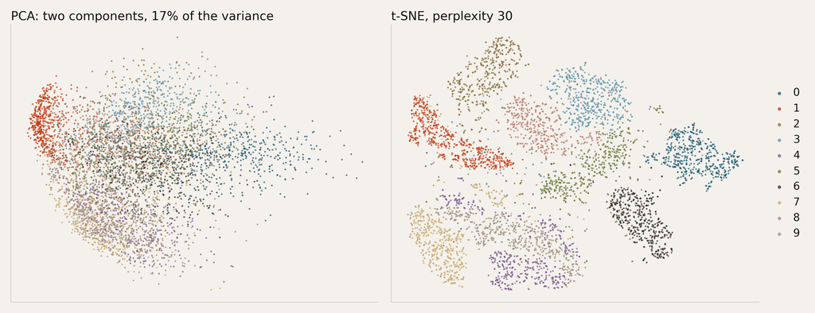

Left: PCA. Two components hold 17% of the variance, and 95% takes 148. The picture is honest: it shows the 17% that fits on paper.

Right: t-SNE. Ten groups, one per digit, and the digits that touch are the ones that look alike, such as 4 and 9.

Same 5,000 digits. PCA can only cut the curved surface with a flat plane; t-SNE follows it. The bet paid off.

2 / when is a flat picture not enough?

MADS-DAV · 12

MNIST, 5,000 digits drawn at random from 70,000, because t-SNE gets slow on many points. That is a decision too: a picture of a sample is a picture of a sample. The pixels are not standardised: all 784 columns share one unit, 0 to 255, and a pixel that varies more between digits should count more. That is the exception from the penguin slide. PCA first. Two components carry 17 percent of the variance; you need 148 for 95 percent. The digits overlap in one smear. That is not wrong: it is a picture of 17 percent of the data, and that number belongs in the title. Then t-SNE with its default setting: ten clumps, one per digit, and the pairs that touch are the pairs people confuse too, 4 and 9 most of all. This is t-SNE doing what PCA cannot: the surface the digits lie on is curved, and a flat plane can only cut through it. Notebook 06.1, section 6.1.4.

■ 2 — when is a flat picture not enough?

t-SNE in a nutshell

## t-SNE: the map must pick the same neighbours

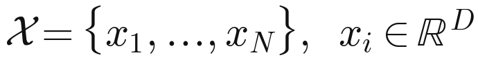

The data: N points with D numbers each, such as 784 pixels.

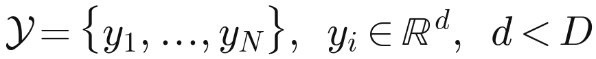

The map: the same N points with d numbers each, usually two.

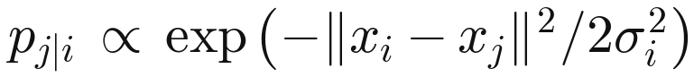

In the data: how likely point i is to pick point j as its neighbour. A normal curve around i, as wide as the perplexity asks.

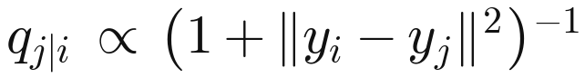

In the map: the same question, with a curve that has heavier tails: the t in t-SNE.

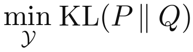

Fit: move the points of the map until Q matches P. The next slide shows the result.

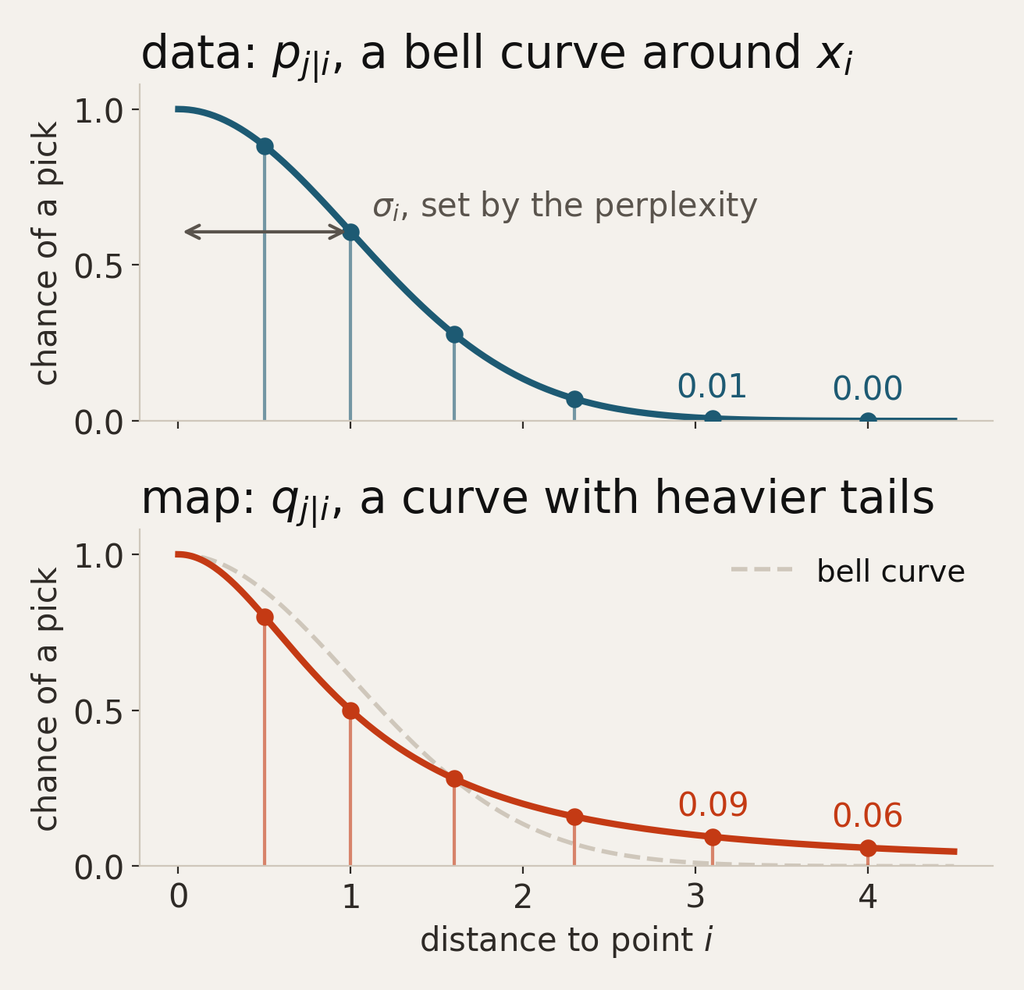

2 / when is a flat picture not enough?

MADS-DAV · 13

How does t-SNE do it? Five ingredients. The data: N points, each with D numbers; for MNIST 5,000 points with 784 numbers each. The map: the same N points, each with d numbers, and d is almost always two. Then, for every pair of points, a probability: if point i had to pick one neighbour, how likely would it pick point j? In the data that follows a normal curve centred on point i, the bell curve you know from z-scores: close points are likely picks, far points almost never. The width of that curve, sigma i, differs per point: narrow in a dense region, wide in a sparse one, set so that every point picks as if from about as many equally likely neighbours as the perplexity says. That is the setting two slides on. In the map the same question is asked with a different curve, the Student t with one degree of freedom, which has heavier tails than the normal curve: there, a point that is only moderately far in the data can be placed far away at little cost. That is where the gaps come from, the gaps in the swiss roll and the space between the MNIST digits. And it is the t in t-SNE. Then the fit: t-SNE starts from a first guess for the map and moves its points step by step until Q looks like P. The mismatch it reduces is the KL divergence, which punishes hardest when two points are neighbours in the data, a large p, and far apart in the map, a small q. The reverse, close in the map but not in the data, it hardly punishes. So neighbours are kept and distances are not, and that is the rule for reading the picture on the next slides. In the actual algorithm the two directions, i picking j and j picking i, are averaged into one p per pair; that changes nothing here. The two formulas in the middle are drawn on the right, against the distance to point i, both scaled to 1 at distance zero. Top, the data: a bell curve, with six example neighbours on it. The close ones are likely picks; from distance 3 on the chance is practically zero, 0.01 and then 0.00. The arrow is sigma i, the width the perplexity sets. Bottom, the map: the t curve, with the bell curve dashed under it. Close by the two are alike; further out the t curve stays well above zero, 0.09 at distance 3 against 0.01. So in the map, a pair that should hardly ever pick each other has to sit further apart than in the data before its q is as small as its p. That is the push behind the gaps.

■ 2 — when is a flat picture not enough?

one point, on the swiss roll

## 25 of its 30 likeliest neighbours stay the same

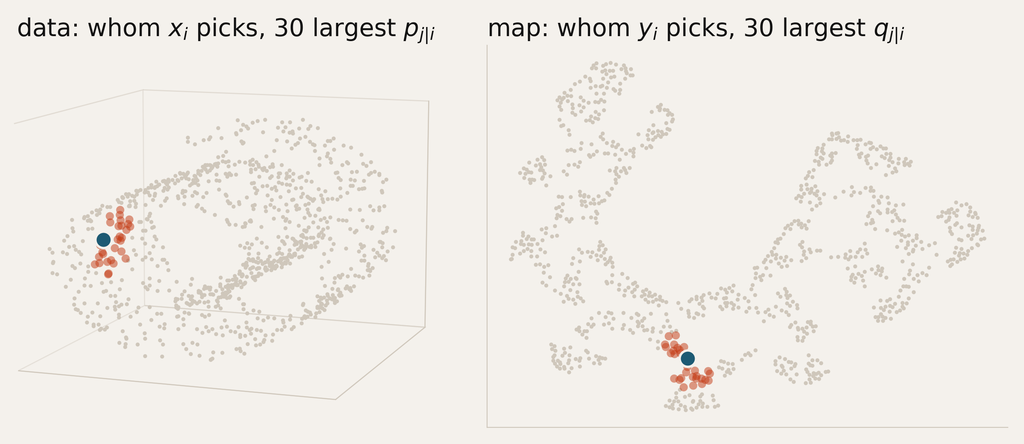

Left: the roll in 3D. The petrol point's 30 likeliest picks by p all lie on its own layer of the sheet.

Right: the finished map. The same point's 30 likeliest picks by q gather around it.

25 of the 30 are the same points. That agreement is what t-SNE fits; where far points end up, it does not.

2 / when is a flat picture not enough?

MADS-DAV · 14

The five ingredients, on data we have seen. The swiss roll from the start of this part, with one point halfway along the sheet and halfway across it, in petrol. Left: the 30 points it is most likely to pick as a neighbour in 3D, the 30 largest p for this point. Thirty because the perplexity is 30. They all lie on its own layer of the sheet; none is across the gap on the next layer. Right: the finished t-SNE map, and the 30 points the same point is most likely to pick there, the 30 largest q. 25 of them are the same points. That agreement is exactly what t-SNE optimised for, and it is all it optimised for: where a point far away on the sheet ended up in the map was never part of the question. That is why the next slides allow only one kind of claim about a t-SNE picture: which points end up together.

■ 2 — when is a flat picture not enough?

one dataset, four perplexities

## Which points group together survives; where the groups sit does not

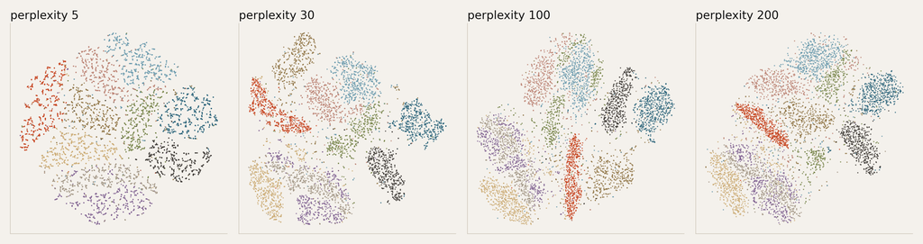

Perplexity is roughly how many neighbours each point tries to stay near. The default is 30. It is a choice, not a display option.

Stable: at every setting the digits come out as groups. The silhouette puts a number on that instead of your eye: 0.20–0.28 each time (1: clearly apart, 0: fully overlapping).

Not stable: at perplexity 5 the two digits furthest apart are 0 and 1, at 200 they are 0 and 7. Distances between groups belong to the setting.

2 / when is a flat picture not enough?

MADS-DAV · 15

The parameter. Perplexity is roughly the number of neighbours each point tries to stay close to. Defaults are where decisions go to hide, so run several. Same 5,000 digits, four values. Two answers, and you need both. Membership is stable. Seeing ten groups in four pictures is not enough, because t-SNE draws groups readily, so put a number on it that you can compare between settings: the silhouette, which comes back several times today. It asks, for every point, how much closer it lies to the other points of its own group, here its true digit, than to the nearest other group, averaged over all points. 1 means tight groups far apart, 0 means groups that run into each other. It stays between 0.20 and 0.28 at every perplexity: modest, because handwriting varies, but the same whichever value you pick, so the digits come out as groups every time. When you say there are groups here, t-SNE backs you up. Geometry is not: the distances between the groups, ranked, agree between perplexity 5 and 100 at a spearman of only 0.41. At perplexity 5 the two digits furthest apart are 0 and 1; at 200 they are 0 and 7. So how far apart two groups sit is a fact about the setting, not about handwriting. What survives every setting is worth reporting: 4 and 9 are the closest pair at both extremes, the confusion anyone would predict. What you may say about a t-SNE picture: which points ended up together, and whether that survives another perplexity. What you may not say: that one group is nearer to a second than to a third, that a gap is wide, that a group is large, or anything about the axes. Notebook 06.1, section 6.1.5.

■ 2 — when is a flat picture not enough?

1,000 points, 50 dimensions, four perplexities

## Preattentive processing: what do you see?

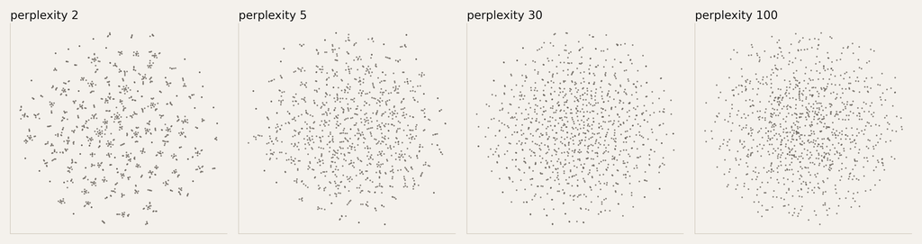

2 / when is a flat picture not enough?

MADS-DAV · 16

There is nothing there: every value is a random draw. Still t-SNE draws clumps at low perplexity, and k-means scores 0.31 on the picture against 0.016 on the data itself.

Show the four pictures and ask what people see. Give it a few seconds; someone will point at the clumps on the left. Then click. This is data with no structure whatsoever: a thousand points, fifty dimensions, every value an independent draw from the same normal distribution. There are no groups. At perplexity 2 the picture still breaks into little clumps: t-SNE was asked to keep each point near its two nearest neighbours, and in fifty dimensions of noise every point has two nearest neighbours, so it obliged. The numbers are worse, and they hold at every perplexity. Run k-means with five groups on the raw data and the silhouette is 0.016: correctly reporting that there is nothing there. Run the same k-means on the two-dimensional picture and it is around 0.31, which anywhere else you would read as decent cluster structure. So never cluster the t-SNE picture. Distances in it are not the data's distances: fifty dimensions have been squeezed into a patch of paper, and anything measuring distance there is measuring the paper. Cluster the data, use the picture to look, and check groups against something you measured another way. Question six comes back to this. Notebook 06.1, section 6.1.6.

■ 2 — when is a flat picture not enough?

PCA or t-SNE?

## Two tools that answer different questions

|  | PCA | t-SNE |
| --- | --- | --- |
| keeps | the overall shape: large distances, main directions | neighbourhoods: who is close to whom |
| loses | curves: it can only flatten | distances between groups, their sizes, the gaps |
| use it to | see the main directions of spread, and what they are made of | see whether points group together |
| report | the share of the variance in the picture | the perplexity, and one other you tried |
| never | read two components as the whole data | cluster the picture, or read its distances |

2 / when is a flat picture not enough?

MADS-DAV · 17

The comparison in one table. PCA is a rotation followed by a shadow: it keeps the overall shape, the large distances and the main directions, and its axes mean something you can read from the loadings. It cannot undo a curve. Use it when you want to know what the main directions of variation are and how much of the data they hold, and report that share. t-SNE is a rearrangement that keeps neighbours together. It can undo a curve, and it gives up everything at a larger scale: the distance between two groups, their size, whether a gap is real, the meaning of the axes. Use it to see whether points group together, and report the perplexity and one other you tried. The two never rows are the mistakes we see in projects every year. A two-component PCA presented as if it were the data, without the share of the variance. And k-means, or any distance, run on a t-SNE picture. In practice the two are often used together: PCA first to bring hundreds of dimensions down to fifty, then t-SNE on those fifty. sklearn's TSNE with init="pca" starts from the PCA picture.

● 02 — when is a flat picture not enough?

PCA flattens. t-SNE unrolls, and forgets distances.

Data on a curved surface needs a method that follows the surface: t-SNE keeps neighbours together.

What survives another perplexity, you may report: which points group together.

Never cluster a t-SNE picture or read its distances: on pure noise it draws groups too.

18

Said again. When data with many columns lies on a curved surface of few dimensions, and images and text usually do, a flat shadow cannot show its groups and t-SNE can. You buy that with everything at a larger scale. So the claim you can make from a t-SNE picture is narrow: these points end up together, at this perplexity and at that one. Everything else in the picture is decoration. And because t-SNE draws groups in random numbers, a group in the picture is a question, not an answer: check it in the data. What to write down in a report, from the end of notebook 06.1: whether you scaled and why, the variance your PCA picture holds, the perplexity and one other you tried, and which of the two claims you are making.

▲ question 03

how does text become a vector?

## Count which three-letter sequences a text contains, and compare the counts.

1 · Count

Every run of three characters is a column, and a text becomes a row of counts: thousands of columns, mostly zeros.

2 · Compare

Add up the differences per column, and two texts differ by so many trigram occurrences.

3 · Check

A count can be read back. Look at what did the work, and at what a meaningless split gives, before you believe a picture.

19

Question three. Before any neural network, the cheapest way to turn text into numbers: count. Which runs of three characters does a text contain, and how often? That gives a row of counts per text, and two rows can be compared. No GPU, no download, seconds on any laptop, and you can read back what the numbers mean. It is also the baseline every learned representation has to beat. The showcase is a real published claim: that the anonymous QAnon posts were written by two different people. We rebuild the method in a few lines and then ask lesson 5's question: what does the picture actually support? The honest answer turns out to be less than it first looks, and finding that out takes two checks that you can use on any project. Notebook 06.2.

■ 3 — how does text become a vector?

two strings, 23 columns

## A trigram is any run of three characters

count

CountVectorizer(analyzer="char", ngram_range=(3, 3))

| text | ·ba | ana | apa | ban | nan | pap |
| --- | --- | --- | --- | --- | --- | --- |
| yellow banana | 1 | 2 | 0 | 1 | 1 | 0 |
| papagena papaya banana | 1 | 2 | 2 | 1 | 1 | 2 |

Six of the 23 columns: the trigrams that occur more than once. · is a space.

Count: every three-character run in all texts becomes a column. 23 here; 27,179 for the Q posts, most of them zero in any one text.

Compare: the Manhattan distance adds up the absolute difference per column. These two strings are 21 apart: they differ by 21 trigram occurrences.

That is why the texts must be the same length: a text twice as long has counts twice as big, and would be far from everything for its length alone.

3 / how does text become a vector?

MADS-DAV · 20

The whole mechanism on two toy strings, from notebook 06.2. A trigram is any run of three consecutive characters, spaces included. CountVectorizer with analyzer char and ngram_range 3,3 finds every trigram that occurs anywhere in the texts, makes each one a column, and counts how often each text contains it. "yellow banana" and "papagena papaya banana" give 23 distinct trigrams; the table shows the six that occur more than once. ana appears twice in each, because banana contains it twice; apa and pap are the second string repeating itself. Most of a row is zero, and that stays true at scale: the Q chunks span 27,179 trigrams and a chunk uses 12 percent of them. Then the distance. Manhattan distance adds up the absolute difference per column, walking the grid block by block instead of cutting the diagonal like Euclidean distance. On counts it reads directly: these two texts differ by 21 trigram occurrences. It is also why the chunks in the next slides all have the same length: Manhattan distance grows with length, so unequal chunks would look different for no reason but their size. This is a lookup table, not a learned model: you choose what to count, it counts.

■ 3 — how does text become a vector?

a published claim, rebuilt

## “QAnon is two different people”

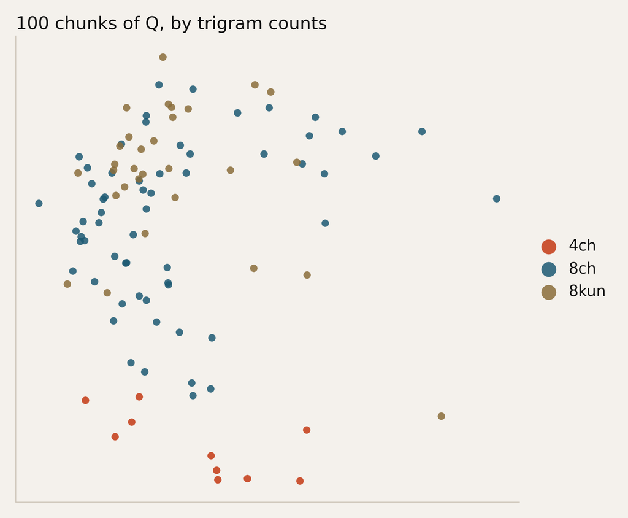

In 2020 the Swiss company OrphAnalytics counted character trigrams in every post by “Q” and concluded: two authors, one on 4chan in 2017 and a second after the move to 8chan.

Rebuilt in a few lines: 4,966 posts, cut into 100 chunks of equal length, counted, compared by Manhattan distance, and drawn with PCA.

The colour is the site, and a site is also a period. The 4chan chunks sit apart, as in the paper.

3 / how does text become a vector?

OrphAnalytics, white paper (2020) · 21

The showcase is a real published claim. In 2020 the Swiss company OrphAnalytics analysed every message posted by Q, the anonymous account behind QAnon, and concluded from the writing style that it was written by two different people: one on 4chan in late 2017, and a second who took over after the move to 8chan. Their method, stripped of the patented-technology language: cut the text into equal chunks, count character trigrams, measure how far apart the chunks are, look at the picture. Four steps, and every one is a decision. We rebuild it in a few lines of sklearn. The posts come from a volunteer project on GitHub; posts under fifty characters are dropped, because a lone Q or a bare link is not a writing sample. The rest is cut into a hundred chunks of about ten thousand characters, counted, compared, and each chunk's row of distances to all the others is projected with PCA. The colour is the site, and the three sites are three periods: 4chan for the first two months, 8chan until 2019, 8kun after. The ten 4chan chunks sit apart. That is the paper's picture, more or less. Now lesson 5's question: what does this picture support?

■ 3 — how does text become a vector?

reading the counts back

## What separates the 4chan months: questions, and links

more common on 4chan

·wh ?·w is· ·th ·is s·t at· hat wha he·

Writing: *what*, *why*, *is*, question marks. The early posts were strings of questions.

more common after the move

ttp htt :// ·ht com tps ps: s:/ .co om/

Links, and nothing else. A link is pasted, not typed, and its domain names the platform rather than the writer.

A writer who moves from 4chan to 8chan and starts answering with links changes their trigram counts without changing who they are. A counter cannot tell the two apart, so remove the links and count again.

3 / how does text become a vector?

MADS-DAV · 22

The advantage of a hand-made vector over a learned one: you can read it back. Per trigram, take its share of a chunk on 4chan minus its share after the move, and list the extremes. Two kinds of thing turn up. The 4chan side is writing: wh, question mark space w, is, what. The early posts were long strings of Socratic questions. The other side is nothing but links: htt, colon slash slash, com, om slash. A link is pasted, not typed, and the domain in it names the platform. So the counter has mixed two different kinds of change: a change in how someone writes, and a change in what the platform makes you paste. The cheapest alternative explanation for the picture, the platform's markup, can be removed: strip the links, keep only letters and spaces, and run exactly the same steps. In the notebook that is the same pipeline with two parameters changed in the NormaliseText step. Lesson 3's rule: check the mechanism before you write it down.

■ 3 — how does text become a vector?

the same posts, counted twice

## Without links and punctuation: what do you see?

pipeline

.add(NormaliseText, column="text", strip_urls=True, letters_only=True)

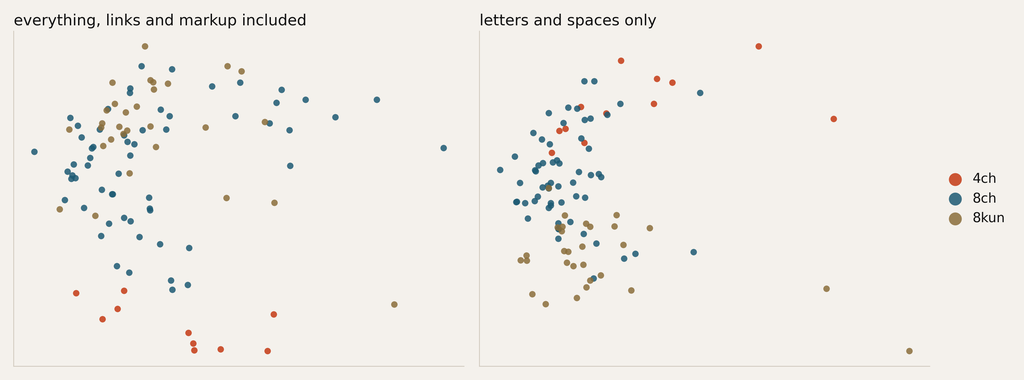

3 / how does text become a vector?

MADS-DAV · 23

The vermilion 4chan chunks no longer sit apart. Some are at the edge, several among the 8chan chunks. The split in the first picture was mostly markup.

Same posts, same steps, one change: before counting, links are removed and only letters and spaces are kept. Ask the room what they see before clicking. Then click: the 4chan chunks no longer sit apart. A few are out at the edge, several sit inside the 8chan cloud. And something else appeared: the 8kun chunks now gather at the bottom. The picture says that most of the separation in the first picture was markup. Keep this picture in mind for the next slide, because the usual number for judging it says the split survived the cleaning, and the next slide shows why that number misses what the picture shows.

■ 3 — how does text become a vector?

a mean that hides the answer

## The number that did not move answered another question

| silhouette, 4chan vs. after | everything | letters only |
| --- | --- | --- |
| mean over all 100 chunks | 0.083 | 0.087 |
| mean over the 4chan chunks | 0.214 | 0.073 |

Silhouette: a number for whether two groups really stand apart in the data, so you need not trust your eye on a picture, and can compare before and after. It asks of every chunk whether it is closer to its own group than to the other. 1: clearly apart. 0: no separation.

The first row is the number you would have reported, and it barely moves. But 90 of the 100 chunks are “after the move”, so it mostly measures them.

The question is about the 4chan chunks. Their own separation drops by two thirds. The picture was right; the mean hid it.

3 / how does text become a vector?

MADS-DAV · 24

The number, and a trap in it. Why a number at all? A picture of 100 chunks invites you to see groups, and two pictures are hard to compare by eye. The silhouette puts one number on the question do these groups really stand apart, so you can compare: everything counted against letters only, real groups against shuffled ones. It scores how well each point sits in its own group: for every chunk, the average distance to the other group minus the average distance to its own group, scaled to between minus one and one. Around zero means the groups do not separate. The usual summary is the mean over all chunks: 0.083 with everything counted, 0.087 with letters only. It does not move, and that is the number an analysis would usually report. But 90 of the 100 chunks are after the move. A mean over all chunks mostly reports how the after-chunks sit with each other, and they became a little more coherent once the links were gone. The question is about the 4chan chunks, so take the silhouette of those chunks alone: 0.214 with everything, 0.073 with letters only, a drop of two thirds. That matches the picture. The general lesson: use the number that answers your question. A summary over a group of 100 that is 90 percent something else answers a question about the something else. Notebook 06.2, section 6.2.5.

■ 3 — how does text become a vector?

what does a meaningless split give?

## Every stretch of time resembles itself

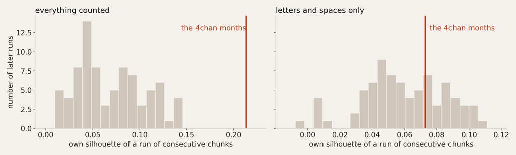

Grey: the same measurement for every later run of consecutive chunks of the same length. Vermilion: the 4chan months.

Everything counted: the 4chan months stand out from every other stretch of the corpus.

Letters only: 25 of 77 later stretches separate better. Chunks from the same weeks share topics, everywhere in the corpus.

3 / how does text become a vector?

MADS-DAV · 25

A silhouette of 0.073 is still above zero, so something is left. Above zero compared to what? Shuffled labels, lesson 5's usual comparison, are the wrong one here. The chunks are in time order, and text written in the same weeks shares topics, so any run of consecutive chunks resembles itself more than a random handful of chunks would. The fair comparison for the first twelve chunks is every other run of twelve consecutive chunks. The grey bars are exactly that: the same own-silhouette for every later stretch of the same length. With everything counted, the 4chan months are more distinct than any other stretch in the corpus; that is the link effect. With letters only, 25 of the 77 later stretches separate better than the 4chan months do. They are an ordinary stretch of time. What is left after the markup is the drift every text corpus has: what someone writes about changes from month to month. The general lesson, and the one to use in your project: compare your finding with what a split that means nothing gives, and choose that comparison so it keeps everything except the thing you claim. Here that is time. In the notebook this is a NullResult and NullPlot, the same tools as lesson 4.

■ 3 — how does text become a vector?

model · mechanism · replication

## This picture is not evidence for two authors

1 · model: fails

Without links, the 4chan months are no more distinct than other stretches of time.

2 · mechanism: two

A new author, or topics that drift over time. Both predict this picture.

3 · replication: none

Not in this data: one corpus, one switch.

In lesson 5’s grid, a mechanism that fails the test is “plausible, unproven”, with a note on what would settle it.

A better picture would not settle it; a different question would. Not “do the chunks differ?” but “whose known writing do they resemble?”

In 2022 two teams did that with texts by candidate authors, and both pointed at the same two people. The claim may be true; this method could not show it.

3 / how does text become a vector?

MADS-DAV · 26

Through lesson 5's grid. The model leg fails: the clear split in the first picture was links, and without them the 4chan months are no more distinct than a dozen consecutive chunks from anywhere else. Mechanism: a second author is one, and a plausible one. But topics drifting over time is another, and it predicts exactly what we see, because every stretch of the corpus resembles itself. Replication: there is none in this data, one corpus with one switch. A claim with a mechanism that fails the test lands in the cell plausible, unproven, and that cell asks you to say what would settle it. Not a better picture of these chunks: no picture can tell a new writer from a drifting one, since the switch of platform and the switch of writer, if there was one, happen at the same moment. A different question can: whose known writing do these chunks resemble? In February 2022 two teams did exactly that, OrphAnalytics again and the French linguists Florian Cafiero and Jean-Baptiste Camps, comparing Q's posts with texts by candidate authors. Both pointed at the same two people, one for the early posts and one who took over around the move, as reported by the New York Times; both men deny it. So the claim may well be true. The trigram picture is not the evidence for it, and with the links left in it looked as if it was.

● 03 — how does text become a vector?

Count, compare, and read back what did the work.

Trigram counts turn text into numbers you can read back: cheap, fast, no training needed.

Reading the counts showed the first split was links. Comparing with other stretches of time showed the rest was drift.

Use the number that answers your question, and compare it with what a meaningless split gives.

27

Said again. Counting characters is the cheapest way to make text into numbers, and its advantage is that you can always read back which counts did the work. That reading is what exposed the links. Two checks then took the claim apart, and both are habits for any project. First, a number has to answer your question: a mean over a hundred chunks did not answer a question about ten of them. Second, compare your finding with what a split that means nothing gives, chosen so that it keeps everything but the thing you claim: here other stretches of time, not shuffled labels. In the notebook you then run the same four steps on your own chat, per author, and see whether typing style separates the people you know are there.

▲ question 04

why use a model somebody else trained?

## Running a large model is expensive; reusing its output is cheap. Pay once, then train on a laptop.

1 · Transfer

Reuse what a model learned from millions of photos for your own task, and train only a small model on top.

2 · The cache

The large model gives the same output for the same photo every time, so compute it once and store it.

3 · Near is similar

In a good vector space similar things lie close together. Cosine similarity measures how close.

28

Question four. Trigram counts were a vector you designed yourself. Most vectors you will use from now on were designed by somebody else: a large neural network, trained by a company with far more data and computers than any of us, turns a photo or a sentence into a few hundred numbers. Three ideas. Transfer learning: what that network learned about photos in general is useful for your task too, so you keep it as it is and train only a small model on top. The cache: because the large network does not change, its output for a given photo never changes either, so you run it once and store the result. That is what makes the rest cheap enough for a laptop, and it is the step most people skip when they first try this, running the big model again and again. And near means similar: in a well-trained vector space, photos of the same flower sit close together, so measuring closeness, with cosine similarity, already gives you a classifier without any training. Notebook 06.3.

■ 4 — why use a model somebody else trained?

oxford flowers, 102 species

## The encoder runs once; the head trains on what it stored

cache

VectorCache.from_hub("pttrn-io/oxford-flowers-dinov2-small", split="train")

photos

5,000 photos of 102 kinds of flower

→

encoder · once

DINOv2-small: 22 million weights, trained by Meta on 142 million photos. Frozen.

→

cache

384 numbers per photo, stored and published on the hub

→

head · yours

39,270 weights, trained on a laptop, as often as you like

Encoder: a network that turns a photo into 384 numbers. It never saw these labels; it learned what makes photos look alike.

Cache: a frozen encoder gives the same vector for the same photo every time. So there is nothing to recompute: store it.

Head: one weight per pair of (number, species). Transfer learning is training only this part.

4 / why use a model somebody else trained?

MADS-DAV · 29

The pipeline of notebook 06.3, left to right. The photos: the Oxford flowers dataset, 102 species. The encoder: facebook/dinov2-small, a network of 22 million weights that Meta trained on 142 million photos to put photos that look alike close together. It has never seen these flower labels. It turns each photo into 384 numbers. Using what it learned for a new task, telling 102 species apart, is transfer learning: you keep the encoder as it is, frozen, and train only a small model on top of its output, the head. Here is the point that matters for your own projects. Training means showing the head the training photos many times; one pass is an epoch. If every epoch ran the photos through the encoder again, you would pay for the encoder every epoch and get exactly the same 384 numbers every time, because a frozen encoder does not change. So you run it once and store the vectors: a vector cache. This one is published on the Hugging Face hub; VectorCache.from_hub downloads 5,000 vectors with their labels and a metadata.json saying which model made them, in under a second, without a GPU. The ML course starts from exactly this.

■ 4 — why use a model somebody else trained?

counting multiplications

## Without a cache, the encoder does nearly all the work, every epoch

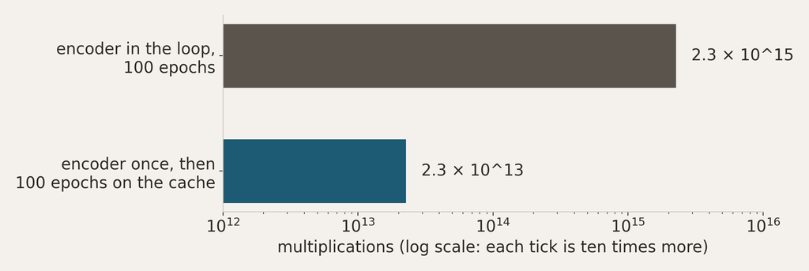

| one photo through | multiplications |
| --- | --- |
| the encoder: 22 million weights × 257 patches | 5,654,000,000 |
| the head: 384 numbers × 102 species | 39,168 |

One photo through the encoder costs 144,000 times what the head costs, and that is a lower bound.

Train 100 epochs with the encoder in the loop, and it computes the same vectors 100 times over.

With the cache, 100 epochs cost about as much as one pass of the encoder. Measured: 100 epochs in 4 seconds on a laptop.

4 / why use a model somebody else trained?

MADS-DAV · 30

How much did the cache save? Count multiplications; the notebook does this in one cell. A photo enters the encoder as patches of 14 by 14 pixels: 256 of them for a 224-pixel photo, plus one summary token, 257 in all. Every one of those passes through each of the encoder's 22 million weights once, so one photo costs about 5.7 billion multiplications. That is a lower bound: the attention between patches comes on top. The head is one weight per pair of number and species, 384 times 102, so 39 thousand multiplications per photo. The encoder costs 144,000 times more. Now training: a hundred epochs over 4,000 training photos. With the encoder in the loop that is 2.3 times ten to the fifteenth multiplications, almost all of it the encoder recomputing vectors it already computed. With a cache it is the encoder once, 2.3 times ten to the thirteenth, plus a hundred epochs of head, which barely adds anything. A hundred times less, and it only gets better with more epochs or more experiments. Measured in the notebook: the head trains a hundred epochs in about four seconds on a laptop CPU. That is why the cache exists. Somebody with a GPU paid for the encoder once; you train the part that is yours.

■ 4 — why use a model somebody else trained?

eight of the 102 species

## An organised space, before anything is trained

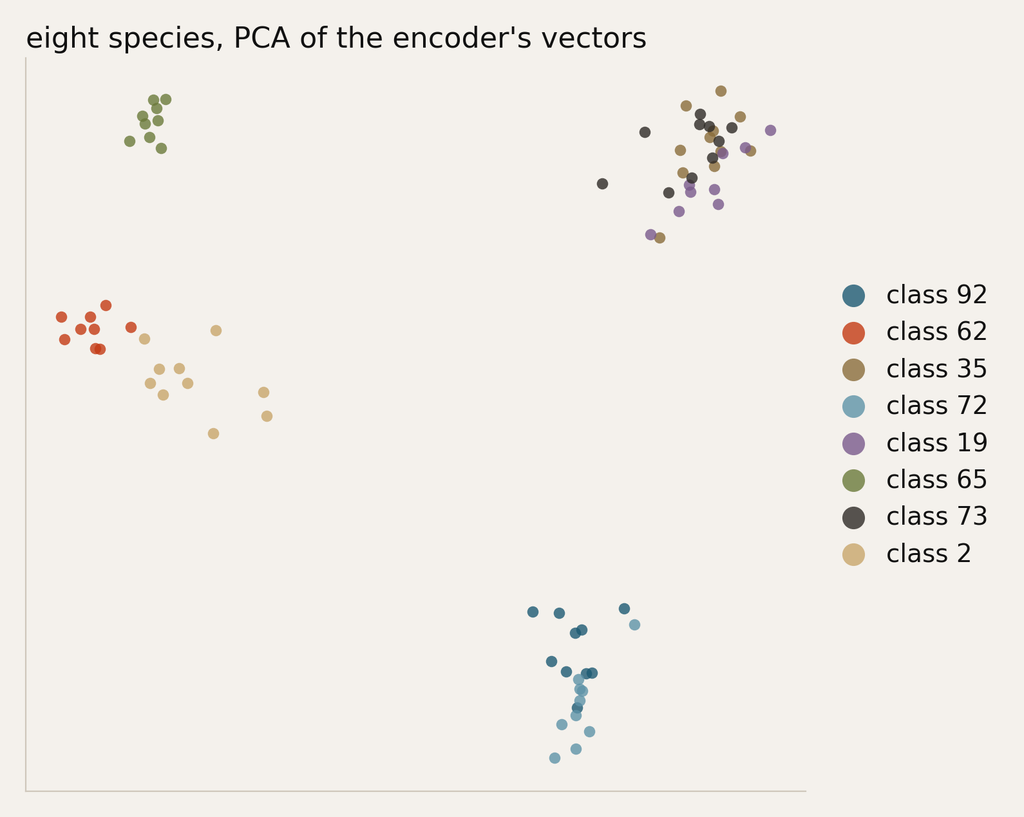

PCA of the encoder’s 384 numbers, two components, coloured by species. Nothing has been trained on these labels.

Photos of one species already sit together. Compare MNIST’s raw pixels: the same two-component PCA gave a smear.

The projection does not create the groups. The encoder had already organised the space; PCA only lets you see it.

4 / why use a model somebody else trained?

MADS-DAV · 31

If the encoder did its job, photos of the same species should already sit near each other: not because anything was fitted to this task, but because near in this space is supposed to mean similar. Eight species, projected with the same PCA as before, is the direct way to look. Eight groups, mostly tight, from a linear projection of raw encoder output. Two or three species overlap in these two components, which is what two components of 384 can do; the nearest-neighbour check two slides on settles whether they overlap in all 384. Compare it with MNIST: two components of raw pixels gave a smear. Here the same method gives groups, because the 384 numbers were already organised by species before PCA touched them. That is what you buy with a trained encoder: a space where near means similar. The labels in this cache are class numbers rather than species names; nothing here needs to know which number is a rose.

■ 4 — why use a model somebody else trained?

two words, three messages

## Cosine similarity compares the direction, not the length

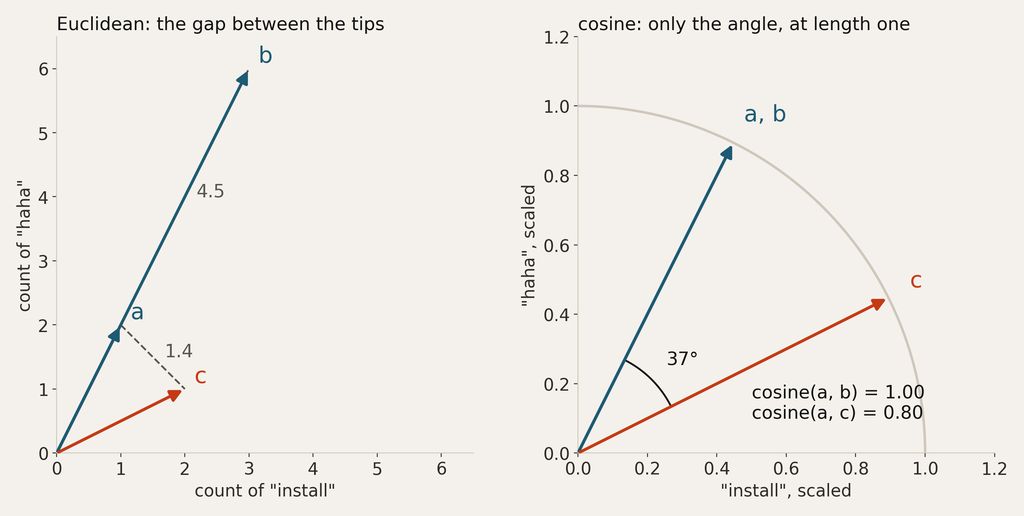

Count two words per message: a = (1, 2); b is a three times over, (3, 6); c = (2, 1), another mix.

Euclidean: a is closer to c (1.4) than to b (4.5). Length decides.

Cosine: the angle. a and b point the same way: 1. c is 37° off: 0.80.

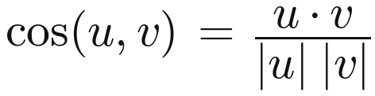

Scale both to length 1 first and the cosine is just the dot product.

4 / why use a model somebody else trained?

MADS-DAV · 32

“Near” needs a measure. The distances so far, Manhattan for the trigram counts and Euclidean in every PCA picture, measure the gap between two points, so a vector's length counts. For text that is often wrong: a long message and a short one can be about exactly the same thing. Make it concrete with vectors you can read: count two words in a message, install and haha. Every message is then an arrow in two dimensions. a is install haha haha, so one and two. b is the same mix, three times as long: three and six, on the same line as a. c is install install haha: two and one, a different mix. Left panel: by Euclidean distance, a is closer to c than to b, so the message that says something else wins over the one that says the same thing three times. Length is doing the work. Right panel: scale every arrow to length one first, so only the direction is left. a and b land on the same spot; the angle between them is zero and the cosine of zero is one. a and c are 37 degrees apart, cosine 0.8. Two messages with no word in common would be at right angles, cosine zero; an embedding can even point the opposite way, minus one. The formula is the right panel written down: the dot product, multiply matching entries and add them up, divided by both lengths. Divide first, by scaling to length one, and the cosine is just the dot product. In 384 dimensions you cannot draw it, and the axes are no longer words but directions the encoder learned, but the arithmetic is the same.

■ 4 — why use a model somebody else trained?

1,000 test photos × 4,000 training photos

## Nearest neighbour: copy the label of the most similar photo

all cosines at once

(test_unit @ train_unit.T).argmax(dim=1)

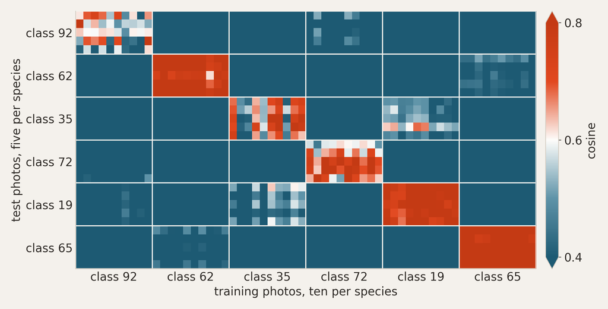

Scale every vector to length 1, and one matrix product gives every cosine at once: a row per test photo, a column per training photo. Shown: a corner, sorted by species.

Red or white on the diagonal, blue elsewhere: a photo is far more similar to its own species (0.70 on average) than to others (0.08).

So the most similar photo is nearly always the same species. Copying its label: 99.1%, with no training. The trained head: 99.3%.

4 / why use a model somebody else trained?

MADS-DAV · 33

The classifier that needs no training. To label a photo you have never seen, find the most similar photo whose label you know, and copy that label. It can only work if the space is organised, if most similar usually means same species, which the PCA picture suggested and this checks in all 384 dimensions. Why the dot product helps: scale every vector to length one, and then the cosine between any test photo and any training photo is a dot product. A matrix product does all of them at once: test times train transposed is a table of 1,000 rows by 4,000 columns, every cosine there is. The nearest neighbour of a test photo is the column with the highest value in its row: argmax. The heatmap is a corner of that table: five test photos and ten training photos for each of six species, sorted by species. The colour scale splits high from low: red from a cosine of 0.8 up, blue from 0.4 down, white at 0.6. The red and white squares on the diagonal say that a photo is far more similar to photos of its own species, 0.70 on average, than to photos of any other, 0.08; a few species are less uniform and stay white, but even those are far from the blue. Its highest cell therefore nearly always sits in its own square, and copying that label is copying the right answer. Done for all 1,000 test photos: 99.1 percent correct on 102 fine-grained species, with nothing trained. The lighter blue blocks off the diagonal are species that look alike; that is where the few mistakes come from. The trained head from the previous slides reaches 99.3 percent, already after one epoch. On a space this well organised there is little left to learn, and you only know that because you computed the baseline first.

● 04 — why use a model somebody else trained?

Pay for the encoder once; train the part that is yours.

A frozen encoder gives the same vector every time: compute it once, store it in a cache, and train a small head on a laptop.

Cosine compares the direction of two vectors. Scale them to length 1 and it is a dot product.

Compute the baseline first: nearest neighbour reached 99.1% without training, and the head added little.

34

Said again. The expensive part of working with a large model is running it, and its output for the same input never changes, so you run it once and store the result. Everything you try on top, a baseline, a head, a hundred epochs, another hundred, then costs almost nothing. That is transfer learning in practice, and it is how question five can embed thousands of chat sessions on a laptop. Cosine similarity is the angle between two vectors, which ignores their length; after scaling to length one it is a dot product, and a matrix product gives all of them at once. Check whether length matters on your data: for these flower vectors it does not, every vector has about the same length and cosine, Euclidean and Manhattan agree to within two tenths of a point. For chat messages, where haha and a three-paragraph story have very different lengths, it does. And a baseline computed without any training is what tells you whether training was worth it.

▲ question 05

what is one row, when a row is “haha”?

## A picture can only show what the rows contain. If you cannot tell who wrote “ok”, neither can a model.

1 · Read the rows

Almost half of all chat messages are five words or fewer. Look at them before you embed them.

2 · Choose a unit

Merge messages into sessions, days or fixed windows, and check which unit holds together.

3 · Choose the tool

An embedding measures meaning. Who is writing lives in how they type.

35

Question five, and the one that matters most for your own project. The flower cache worked because one row was one flower: a clean photo with a clean label. Chat data offers no such luck. What happens to most students is this: they embed every message, draw the picture, colour it by author, and get a blob. Then they try to fix the picture. The better question is the one lesson 1 started with: what is one row? We follow that path step by step on the IRC channel #ubuntu-uk, six people who wrote a lot: the blob and why it is the right answer, three ways to merge messages into larger units, a check of which unit holds together that needs no labels, what an embedding measures and what it does not, a race between two kinds of vector, and a sentiment model checked against labels the writers typed themselves. Notebook 06.4, which ends with the same steps on your own chat.

■ 5 — what is one row, when a row is “haha”?

#ubuntu-uk · six authors · ten random messages

## Who wrote these?

so a small alarm bell is ringing to me

!

not compared to other policitians ofc

“that many keys” - no, one key

maps|wrk: from memory nearly 12 hours

because I’m a developer

yeah that’s definitely not good

like it? based on what?

i was more expecting a sort of terminal server for CAD users :D

what’s the M stand for?

5 / what is one row, when a row is “haha”?

MADS-DAV · 36

Nobody can tell. There is nothing in these lines about who wrote them, and 45% of all messages have five words or fewer. An embedding has no source but the words.

Before embedding anything, read some rows the way the model will get them: one at a time, without context, without a name. These are the first ten of the 1,500 messages the notebook samples from the six busiest people in #ubuntu-uk. Ask the room: who wrote the exclamation mark? Who wrote like it, based on what? Give it a moment, then click. Nobody can tell, and nobody could: there is nothing in these lines about their writer. The median message is six words, and 45 percent have five words or fewer. Keep that in mind for the next slide. An embedding turns every message into 384 numbers, but it has no other source than the words. More dimensions do not add information that the words do not carry.

■ 5 — what is one row, when a row is “haha”?

1,500 messages, embedded one at a time

## One message per row: no authors in the picture

embed

SentenceTransformer("sentence-transformers/all-MiniLM-L6-v2").encode(messages)

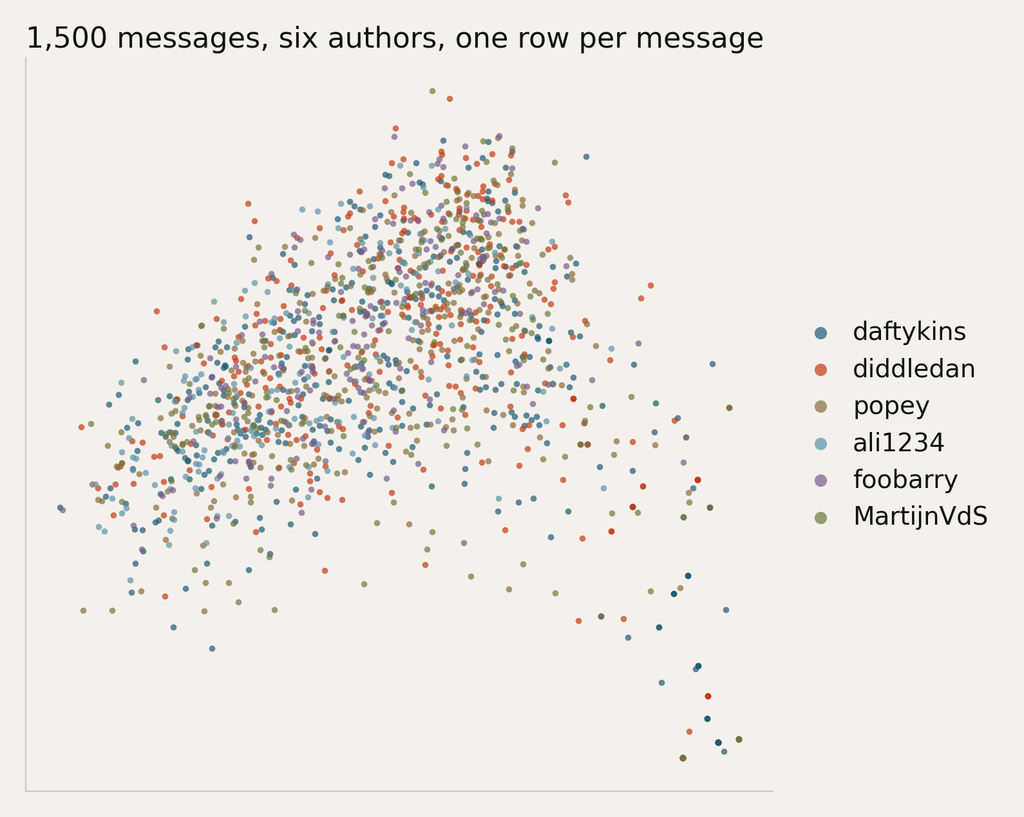

Every message becomes 384 numbers from a small sentence encoder; then PCA, coloured by author.

A blob, and a silhouette by author of 0.00 in all 384 dimensions: not just in the picture.

That is the right answer. The encoder puts similar meanings close together, and “thanks!” means the same thing whoever types it.

5 / what is one row, when a row is “haha”?

MADS-DAV · 37

The picture most students make first. Every message goes through a small, freely available sentence encoder, all-MiniLM-L6-v2, which turns a sentence into 384 numbers the same way the flower encoder did for photos: trained once by somebody else, so that sentences with similar meanings end up close together. Then PCA, coloured by author. A blob. And the silhouette by author is zero in all 384 dimensions, so this is not the projection hiding something: there is nothing to hide. That is the correct answer, and nothing failed. The encoder did exactly what it was trained for. A three-word message carries almost nothing about its writer, so its vector does not either. If you cannot tell the authors apart by reading the messages, a model that gets nothing but those messages cannot either, however many dimensions it has. The instinct at this point is to rescue the picture. Question six is about the most common rescue. The better move is to change the row.

■ 5 — what is one row, when a row is “haha”?

one person, one day, three ways

## Three ways to merge messages into one row

sessions

sessionize(uk, "timestamp", "author", fit_session_threshold(...))

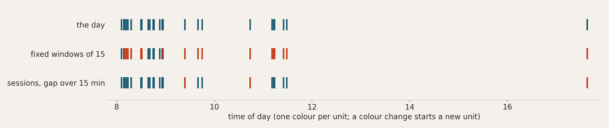

Day: everything one person said on one calendar day, however many conversations that was.

Fixed window: every 15 messages from one person, cut wherever the 15th falls.

Session: a new unit after a pause of more than 15 minutes. That number comes from lesson 4’s exponential fit to the gaps, not from a guess.

5 / what is one row, when a row is “haha”?

MADS-DAV · 38

The fix: merge consecutive messages from the same person into a larger unit. Three ways, shown on one person's day: 47 messages by MartijnVdS on 16 January 2013, one tick per message, and a colour change where a new unit starts. A day: everything that person said that day, in one unit. A fixed window: every 15 messages, cut wherever the fifteenth falls, whatever is going on. A session: a new unit whenever the pause since that person's previous message is longer than a threshold. The threshold should not be guessed. Lesson 4 fitted an exponential distribution to the gaps between messages under an hour, the regime of people talking in bursts. The same fit gives the number sessions need: the gap beyond which a next message looks more like a new start than a reply. On #ubuntu-uk that is 15.2 minutes, read off the fit. In the code that is fit_session_threshold, sessionize and merge_messages from scripts/sessionize.py; the same three functions run on your own chat at the end of the notebook. Three defensible answers. Which one is best is a question you can test, on the next slide.

■ 5 — what is one row, when a row is “haha”?

a check without labels

## Does the second half of a unit belong with its first half?

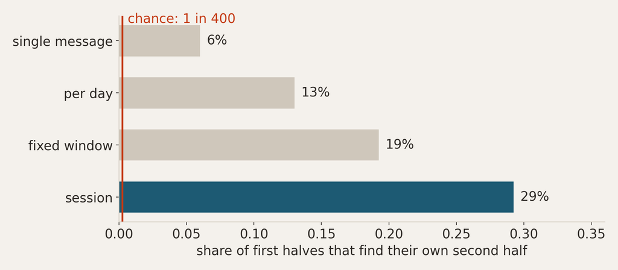

A unit about one thing continues itself. Cut it in half, embed both halves, and let each first half look for its own second half among 400, by cosine.

Predict first: a session is one conversation, a window cuts through one, a day mixes several.

Sessions win. Days hold more text and still lose: what counts is whether the text belongs together.

5 / what is one row, when a row is “haha”?

MADS-DAV · 39

Three defensible units and no ground truth to score them against. So think about what a good unit should be: about something, one conversation, one topic. What would you expect of such a unit? That its second half continues its first half. If someone spends ten minutes on a broken printer, the last five minutes are still about the printer, and you could match the two halves up even if they were shuffled among hundreds of others. That gives a check without any labels. Cut every unit in half by time, embed both halves, and for each first half look for the most similar second half by cosine. If it finds its own, the unit held together. Ask the room to predict the order before showing the bars. A session is one stretch of talking without a long pause, usually one conversation. A fixed window is cut wherever message fifteen falls and can span two conversations. A day mixes every conversation of that day. Two single messages from the same session have very little to match on. The result: sessions 29 percent, fixed windows 19, days 13, single messages 6. With 400 candidates, chance is one in 400, so all of them are far above chance, but the differences are what the check is for. And note that days and fixed windows contain more text than a typical session and still lose. It is not the amount of text; it is whether the text belongs together. Here a cluster in the embedding means about the same thing, which is exactly what this check relies on. It is not the same as written by the same person, which is the next slide.

■ 5 — what is one row, when a row is “haha”?

the same six people, two instruments

## Near in meaning, not in habit

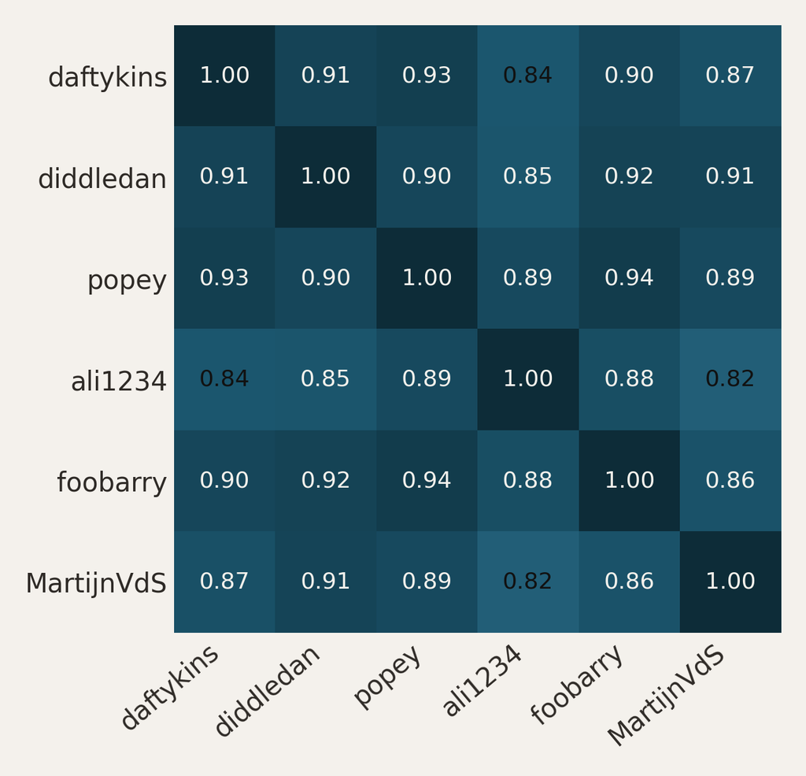

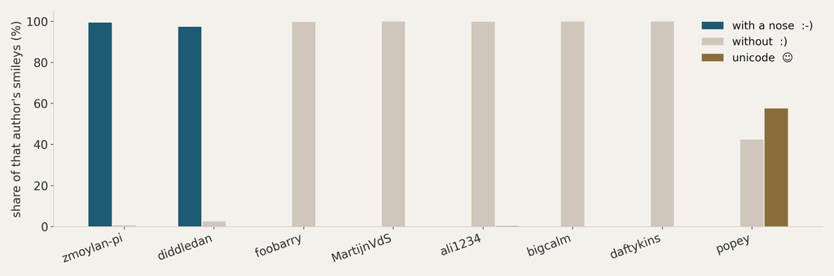

Left: each author’s average session vector, compared by cosine. Every pair 0.82–0.94: six people, nearly one direction.

An embedding is trained to ignore style: “dont” and “don’t” mean the same. For who is writing, a regex looks at the right thing.

5 / what is one row, when a row is “haha”?

MADS-DAV · 40

What is a merged, embedded corpus good for? Finding what is similar to one thing: in the notebook, a session about running out of memory on a computer without swap finds, as its nearest neighbour, a session about reserving memory for a GPU, written by someone else. That is retrieval by topic, which is what the encoder was trained for. Now ask whether similar lines up with who wrote it. The sessions do not group by author: the silhouette is zero again, now on units of dozens of words. And the average session vectors of the six people all point in nearly the same direction, 0.82 to 0.94. Everyone in this channel talks about Ubuntu, computers and their day. Lesson 5 told these same people apart cleanly, with regexes: a smiley with a nose or without, the unicode smiley that one person types and nobody else, dropped apostrophes. That signal is style, punctuation and spelling, and a sentence embedding is trained to ignore it: dont and don't mean the same thing, so they should land in the same place. A model measures what it was trained to measure. For the question who is writing, a handful of regexes beat 384 learned dimensions here, because they look at the right thing. The next slide turns that impression into a number.

■ 5 — what is one row, when a row is “haha”?

same task, same classifier, two vectors

## A race: which vector knows who is writing?

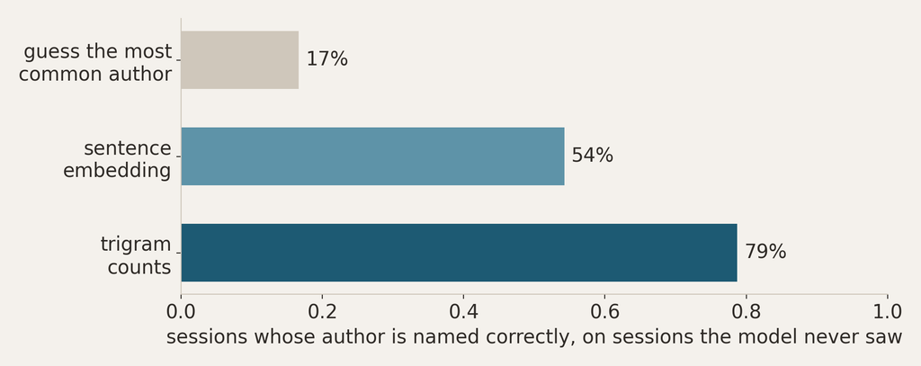

| author | strongest trigrams |
| --- | --- |
| diddledan | ·:- :-p lol ?!· |
| daftykins | ·:d ·:> ah· |
| popey | ·☻· hah nt· (dont) |

Task: name which of six people wrote a session. Logistic regression, as in lesson 5; at most 600 sessions per person; scored on sessions the model never saw.

Only the vector differs. Trigram counts 79%, sentence embedding 54%, guessing 17%.

The trigram weights are lesson 5’s habits, found by the model on its own: smileys and missing apostrophes.

5 / what is one row, when a row is “haha”?

MADS-DAV · 41

Why think of a race at all? The previous slide is an impression from a heatmap: the embedding seems to know what people talk about and little about who they are. Lesson 5 found these same people easy to tell apart by how they type. A race turns both impressions into one number each. Give two kinds of vector the same task, the same classifier and the same data, change nothing but the vector, and see which gets further. Each piece is a decision. The task: read one session and name which of the six wrote it. The vectors: character-trigram counts from question three, which see style, and the sentence embedding, which sees meaning. The classifier: logistic regression, as in lesson 5, one weight per feature per author; the author with the highest weighted sum wins. The same classifier for both, so a difference comes from the vectors. Fair data: at most 600 sessions per person, so nobody wins by always guessing the busiest one, and 70 percent to learn from and 30 percent to score on, sessions the model never saw; scoring on the training sessions would measure memory. The baseline: always guessing the most common author, one in six. Result: counting characters names the author of about four sessions in five, the embedding about one in two. And the trigram model's weights can be read. diddledan: colon dash p, lol, question mark exclamation mark. daftykins: colon d, colon greater-than. popey: the unicode smiley and n-t space, as in dont and cant. For MartijnVdS: s colon space, a nickname followed by a colon: this person addressing someone. These are lesson 5's habits, found by the model by itself from raw character counts.

■ 5 — what is one row, when a row is “haha”?